# Computer exercise 3: solutions

## Solution 1

```r
count(liver, failure)
```

```
#>      failure    n
#> 1   censored 1501
#> 2  rejection   29
#> 3 thrombosis   73
#> 4  recurrent   42
#> 5      other  116
```

1761 patients, 260 graft failures and 1501 censored observations. Note that `status` is 1 for 265 patients while `cof` is non-zero for 260, so the two indicators are not perfectly consistent in the distributed file!

2. Yes. Death with a functioning graft precludes subsequent graft failure. Ending follow-up at death is appropriate for estimating the cause-specific hazard among patients who are alive with a functioning graft. For a cumulative incidence analysis, coding death as censoring leaves it out of the set of competing events. The resulting estimates do not measure the probability of graft failure before death.

To estimate that probability, record death with a functioning graft as a fifth event type and keep the four types of graft failure as the outcomes of interest. Adding the five cumulative incidences would answer a separate question about the probability of graft failure or death. The distributed data do not separately identify the deaths with a functioning graft, so we cannot estimate the five-event version from this file.

3. The cause-specific cumulative incidence function $F_j(t) = P(T \le t, C = j)$ gives the probability of failure from cause $j$ by time $t$ in the presence of the competing causes. It can be estimated over the observed follow-up when the competing events are recorded and the usual independent censoring assumption holds. Its limit as $t$ increases is the probability that cause $j$ ever occurs.

The cause-specific survivor function $S_j^\dagger(t)$ is derived from the hazard of cause $j$ alone. Interpreting it as the survivor function if all other causes were removed assumes that removing them would leave the hazard of cause $j$ unchanged.

4. The Kaplan–Meier estimate of the overall survivor function uses the event and censoring times regardless of the cause labels. Reassigning events to or from cause $j$ can change its cumulative incidence function. Splitting a competing cause into subtypes preserves both the events of type $j$ and the overall survivor function, so the cumulative incidence of cause $j$ stays the same.

## Solution 2

1. **True.** Because the causes are mutually exclusive, the probability of some event in a short interval is the sum over causes, and the hazards add: $h(t) = \sum_j h_j(t)$, hence $S(t) = \exp\{-\sum_j H_j(t)\}$.
2. **True.** The joint distribution of $(T_1, \dots, T_m)$ is not identifiable from competing risks data. For an uncensored observation, we see the earliest failure time and its cause.
3. **False.** If all cause-specific hazards are unchanged, then so is $S(t)$, and hence every cumulative incidence function. The cumulative incidence of cause $j$ is $F_j(t) = \int_0^t h_j(u)\,S(u)\,du$, and $S(u)$ contains the hazards of *all* causes. A variable can leave $h_j$ alone and still change $F_j$ by changing the hazard of a competitor.

## Solution 3

*(Collett, Sections 12.2.1 and 12.3.2, and Tables 12.2–12.4.)*

The day-18 observation in Table 12.2 is a rejection. The full data also contain a thrombosis on that day.

1. The cause-specific data are obtained by turning the other cause into censoring:

```r
t_end <- max(d8$time)
helper <- function(cause) {
  km <- survfit(Surv(time, failure == cause) ~ 1, data = d8)
  1 - summary(km, times = t_end, extend = TRUE)$surv
}

(km8 <- tibble(failure = unique(d8$failure)) |>
  mutate(p = map_dbl(failure, helper)))
```

```
#> # A tibble: 2 × 2
#>   failure        p
#>   <fct>      <dbl>
#> 1 rejection  1
#> 2 thrombosis 0.643
```

Two mutually exclusive events cannot have probabilities whose sum exceeds 1. Here the sum is 1.64, so the Kaplan–Meier complements cannot be the observed-world failure probabilities for the two causes.

```r
(ci8 <- cuminc(Surv(time, failure) ~ 1, data = d8) |> tidy(times = t_end))
```

```
#> # A tibble: 2 × 12
#>    time outcome    estimate std.error conf.low conf.high n.risk n.event n.censor
#>   <dbl> <chr>         <dbl>     <dbl>    <dbl>     <dbl>  <int>   <int>    <int>
#> 1   370 rejection       0.5     0.238   0.0695     0.835      1       4        0
#> 2   370 thrombosis      0.5     0.203   0.113      0.802      1       4        0
#> # ℹ 3 more variables: cum.event <int>, cum.censor <int>, time_max <dbl>
```

Both cumulative incidences are 0.5 and they sum to 1. Half of the patients failed from each cause, and all patients failed by the end of follow-up.

3. $1 - \hat S_j(t)$ estimates the complement of the cause-specific survivor function, $1 - S_j^\dagger(t) = 1 - \exp\{-H_j(t)\}$. It equals $F_j(t)$ if the overall survivor function $S(u)$ and the cause-specific survivor function $S_j^\dagger(u)$ agree at the times up to $t$ when the hazard of cause $j$ is positive. This includes the case of a single cause and the case where the competing causes first occur after time $t$.
4. Because $F_j(t) = \int_0^t h_j(u)\,S(u)\,du$, and $S(u)$ is the survivor function of *all* causes pooled. Both estimators use the same risk set just before a given failure time. In Table 12.4 each cause-$j$ event fraction is weighted by the estimated probability of still being event-free just before that time. The cause-specific Kaplan–Meier product uses only the cause-$j$ event fractions in its factors.

## Solution 4

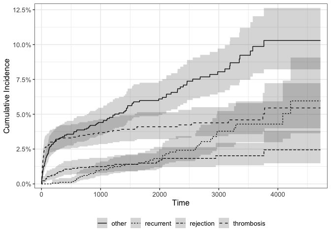

```r
ci <- cuminc(Surv(time, failure) ~ 1, data = liver)
ggcuminc(ci, outcome = levels(liver$failure)[-1]) +
  add_confidence_interval() +
  scale_ggsurvfit()
```

The shape is the one described in Example 12.4: failure from other causes has the largest incidence and rejection the smallest.

```r
(ci12 <- tidy(ci, times = 4380))
```

```
#> # A tibble: 4 × 12
#>    time outcome    estimate std.error conf.low conf.high n.risk n.event n.censor
#>   <dbl> <chr>         <dbl>     <dbl>    <dbl>     <dbl>  <int>   <dbl>    <dbl>
#> 1  4380 other        0.103    0.0112    0.0822    0.126      41     114     1459
#> 2  4380 recurrent    0.0595   0.0138    0.0363    0.0907     41      42     1459
#> 3  4380 rejection    0.0245   0.00589   0.0148    0.0381     41      29     1459
#> 4  4380 thrombosis   0.0545   0.00825   0.0399    0.0723     41      73     1459
#> # ℹ 3 more variables: cum.event <dbl>, cum.censor <dbl>, time_max <dbl>
```

The four estimates are close to Collett’s graphical readings. The curves have already plateaued by 4380 days in these data. That plateau gives the same estimates as at the end of observed follow-up. Estimating the probability over an unlimited time horizon would require assumptions about what happens beyond follow-up.

```r
(comp <- mutate(
  ci12,
  km_complement = map_dbl(outcome, \(x) {
    1 -
      summary(
        survfit(Surv(time, failure == x) ~ 1, data = liver),
        times = 4380,
        extend = TRUE
      )$surv
  })
) |>
  select(outcome, cumulative_incidence = estimate, km_complement))
```

```
#> # A tibble: 4 × 3
#>   outcome    cumulative_incidence km_complement
#>   <chr>                     <dbl>         <dbl>
#> 1 other                    0.103         0.110
#> 2 recurrent                0.0595        0.0693
#> 3 rejection                0.0245        0.0273
#> 4 thrombosis               0.0545        0.0581
```

The Kaplan–Meier complements are larger for all four causes. The estimated probability of any coded graft failure by 4380 days is 0.24. For each cause, the other coded graft failures reduce the overall survivor function only modestly at times when that cause occurs. The overall and cause-specific survivor functions used to weight the event fractions are therefore close.

```r
sum(ci12$estimate)
```

```
#> [1] 0.24
```

```r
(one_minus_S <- 1 -
  summary(
    survfit(Surv(time, cof > 0) ~ 1, data = liver),
    times = 4380,
    extend = TRUE
  )$surv)
```

```
#> [1] 0.24
```

```r
all.equal(sum(ci12$estimate), one_minus_S)
```

```
#> [1] TRUE
```

```r
with(liver, table(status, cof > 0))
```

```
#>
#> status FALSE TRUE
#>      0  1493    3
#>      1     8  257
```

Both estimates are 0.241451. The identity $\sum_j \hat F_j(t) = 1 - \hat S(t)$ uses the same events on both sides. Using `status` for the Kaplan–Meier estimate changes which rows count as events, as the cross-tabulation shows.

## Solution 5

1. With the formula interface in `tidycmprsk`, `Surv()` interprets the first factor level as censoring. Here that level is `"rejection"`. All rows with `cof == 0` also become `NA` because the value 0 is missing from the factor levels. The fit reports that it omitted those rows. With `cmprsk::cuminc()`, the censoring code is set by `cencode`, which defaults to `0`.
2. Include the code 0 as the first factor level and label it `"censored"`. That is the coding used in `liver$failure`.

```r
tidy(cuminc(Surv(time, failure) ~ 1, data = liver), times = 4380)
```

```
#> # A tibble: 4 × 12
#>    time outcome    estimate std.error conf.low conf.high n.risk n.event n.censor
#>   <dbl> <chr>         <dbl>     <dbl>    <dbl>     <dbl>  <int>   <dbl>    <dbl>
#> 1  4380 other        0.103    0.0112    0.0822    0.126      41     114     1459
#> 2  4380 recurrent    0.0595   0.0138    0.0363    0.0907     41      42     1459
#> 3  4380 rejection    0.0245   0.00589   0.0148    0.0381     41      29     1459
#> 4  4380 thrombosis   0.0545   0.00825   0.0399    0.0723     41      73     1459
#> # ℹ 3 more variables: cum.event <dbl>, cum.censor <dbl>, time_max <dbl>
```

3. In the `mice` data every mouse dies, and there are three causes:

```r
count(mice, causeofdeath)
```

```
#>   causeofdeath  n
#> 1            1 51
#> 2            2 53
#> 3            3 77
```

If the factor has only the three cause levels, then `"thymic"` — the first level — is treated as censoring. The thymic lymphoma incidence is then missing from the plot, and, worse, the other two cumulative incidences are computed as if the thymic lymphoma deaths had been censored, which is wrong. The fix is the same: include a `0 = censored` level even though no such observation exists.

## Solution 6

1. Risk table, confidence interval and percent scale was not asked for but is easy to add as well:

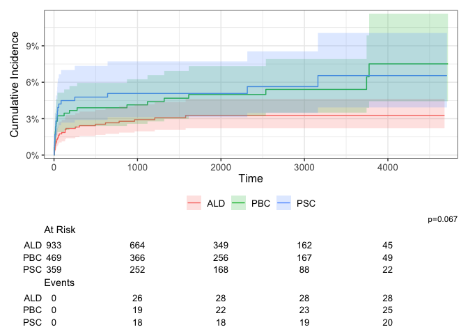

```r
ci_d <- cuminc(Surv(time, failure) ~ disease, data = liver)
ggcuminc(ci_d, outcome = "thrombosis") +
  add_risktable() +
  add_confidence_interval() +
  scale_ggsurvfit() +
  add_pvalue()
```

The incidence is similar in PBC and PSC and clearly lower in ALD, as Collett describes.

2. The figure shows the p-value for Gray’s test. At the 5 % level the test does not reject equality of the cumulative incidence functions for thrombosis across diseases.
3. Gray’s test compares the **cumulative incidence functions** across groups. The log-rank test applied to a cause-specific data set (other causes censored) compares the **cause-specific hazards**. Those are two different null hypotheses, and they can disagree: a variable can have no effect on the cause-specific hazard of an event and still change its cumulative incidence, because the competitors change. Use Gray’s test to compare the probabilities of thrombosis over time. Use a cause-specific log-rank test to compare the instantaneous rates of thrombosis among patients who still have a functioning graft and are under observation.

## Solution 7

```r
graft_causes <- levels(liver$failure)[-1]
cs_liver <- map(setNames(graft_causes, graft_causes), \(x) {
  coxph(
    Surv(time, failure == x) ~ age + gender + disease,
    data = liver,
    ties = "breslow"
  )
})
modelsummary::modelsummary(
  cs_liver,
  exponentiate = TRUE,
  estimate = "{estimate} ({conf.low}, {conf.high})",
  statistic = NULL,
  output = "markdown"
)
```

|  | rejection | thrombosis | recurrent | other |
| --- | --- | --- | --- | --- |
| age | 0.966 (0.931, 1.002) | 0.977 (0.955, 1.000) | 0.979 (0.950, 1.009) | 1.027 (1.006, 1.048) |
| gendermale | 0.597 (0.260, 1.371) | 1.073 (0.606, 1.901) | 0.890 (0.439, 1.804) | 0.921 (0.592, 1.432) |
| diseasePBC | 0.681 (0.243, 1.906) | 1.804 (0.942, 3.458) | 0.343 (0.117, 1.012) | 0.657 (0.382, 1.133) |
| diseasePSC | 1.145 (0.462, 2.835) | 1.613 (0.890, 2.921) | 1.755 (0.896, 3.440) | 1.337 (0.858, 2.083) |
| Num.Obs. | 1761 | 1761 | 1761 | 1761 |
| AIC | 416.0 | 1060.3 | 554.9 | 1638.0 |
| BIC | 437.9 | 1082.2 | 576.8 | 1659.9 |
| RMSE | 0.13 | 0.20 | 0.15 | 0.26 |

The estimates are close to Table 12.5. The code uses Breslow’s method for tied event times, as in Section 17.12.1.

2. Among patients still alive with a functioning graft at the same time since transplantation, and with the same gender and primary disease, one year higher age at transplantation is associated with an estimated 2.7 % higher instantaneous rate of graft failure from causes in the “other” category.
3. No. Every gender confidence interval includes 1. There is no evidence in these data that the hazard of any cause of graft failure differs between men and women once age and disease are taken into account.
4. Treating a competing event as censoring in the Cox input removes the patient from the risk set at that event. The hazard ratio describes the relative rate among those who are still event-free in the observed setting. To interpret that ratio in a setting where competing causes are removed, their removal would have to leave the cause-specific hazards being compared unchanged. The cumulative incidence function depends on the hazards of all causes, so the hazard ratio for one cause alone cannot determine it.

## Solution 8

```r
fg_liver <- map(setNames(graft_causes, graft_causes), \(x) {
  crr(Surv(time, failure) ~ age + gender + disease, data = liver, failcode = x)
})
modelsummary::modelsummary(
  fg_liver,
  exponentiate = TRUE,
  estimate = "{estimate} ({conf.low}, {conf.high})",
  statistic = NULL,
  output = "markdown"
)
```

|  | rejection | thrombosis | recurrent | other |
| --- | --- | --- | --- | --- |
| age | 0.965 (0.928, 1.004) | 0.977 (0.957, 0.997) | 0.979 (0.950, 1.008) | 1.028 (1.008, 1.049) |
| gendermale | 0.599 (0.274, 1.307) | 1.079 (0.666, 1.747) | 0.887 (0.453, 1.738) | 0.915 (0.591, 1.416) |
| diseasePBC | 0.689 (0.248, 1.914) | 1.833 (1.059, 3.171) | 0.353 (0.127, 0.984) | 0.654 (0.381, 1.123) |
| diseasePSC | 1.101 (0.439, 2.765) | 1.592 (0.869, 2.914) | 1.685 (0.836, 3.394) | 1.303 (0.833, 2.038) |
| Num.Obs. | 1761 | 1761 | 1761 | 1761 |
| Log.Lik. | -206.267 | -528.476 | -279.152 | -821.035 |

The estimates are close to Table 12.6, with some differences for the “other” category. The thrombosis results match the R output in Section 17.12.3.

```r
thrombosis <- list(coxph = cs_liver$thrombosis, crr = fg_liver$thrombosis)
map(thrombosis, tidy, conf.int = TRUE, exponentiate = TRUE) |>
  list_rbind(names_to = "model") |>
  select(model, term, estimate, conf.low, conf.high, std.error, p.value)
```

```
#> # A tibble: 8 × 7
#>   model term       estimate conf.low conf.high std.error p.value
#>   <chr> <chr>         <dbl>    <dbl>     <dbl>     <dbl>   <dbl>
#> 1 coxph age           0.977    0.955     1.00     0.0119  0.0535
#> 2 coxph gendermale    1.07     0.606     1.90     0.292   0.809
#> 3 coxph diseasePBC    1.80     0.942     3.46     0.332   0.0753
#> 4 coxph diseasePSC    1.61     0.890     2.92     0.303   0.115
#> 5 crr   age           0.977    0.957     0.997    0.0104  0.025
#> 6 crr   gendermale    1.08     0.666     1.75     0.246   0.76
#> 7 crr   diseasePBC    1.83     1.06      3.17     0.280   0.03
#> 8 crr   diseasePSC    1.59     0.869     2.91     0.309   0.13
```

For thrombosis, the standard errors on the log scale are smaller in the Fine and Gray model for age, gender and PBC, and slightly larger for PSC. Both models use the same thrombosis events, with different risk sets and variance calculations. The larger Fine and Gray risk set offers no general guarantee of smaller standard errors.

For PBC versus ALD, the two point estimates are close, but the smaller Fine and Gray standard error gives a narrower confidence interval that excludes 1. The two tests concern different parameters. One compares the cause-specific hazard among patients still at risk and the other compares the subhazard linked to the cumulative incidence function.

## Solution 9

1. The subhazard is the derivative of the cumulative incidence function divided by $1 - F_j(t)$. The denominator is the probability of still being event-free or of having already had a competing graft failure. In the fit, individuals retained after a competing event are weighted to account for censoring. The subhazard ratio compares PBC with ALD at the same age and gender. Under the fitted proportional subhazards model, a ratio greater than 1 gives a higher predicted cumulative incidence for PBC when the baseline cumulative incidence is positive and below 1.

```r
fit <- riskRegression::FGR(
  Hist(time, cof) ~ age + gender + disease,
  data = liver,
  cause = 2
)

newdata <- tibble(
  age = 60,
  gender = factor("female", levels = levels(liver$gender)),
  disease = factor(c("ALD", "PBC"), levels = levels(liver$disease))
)

pred <- riskRegression::predictRisk(fit, newdata, times = 3650)
pred
```

```
#>       [,1]
#> [1,] 0.027
#> [2,] 0.050
```

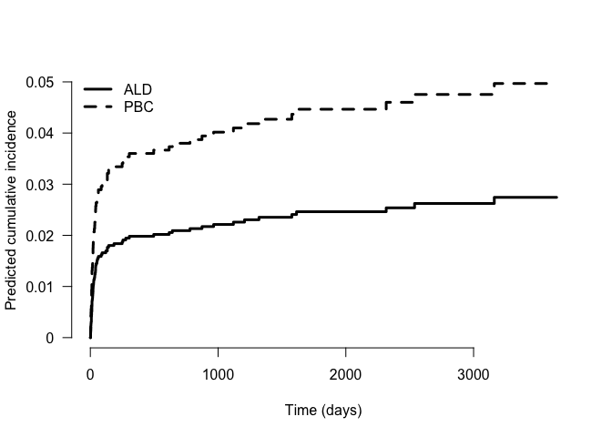

```r
times <- sort(unique(c(0, liver$time[liver$cof == 2], 3650)))
risk_ticks <- pretty(c(0, max(pred)))
riskRegression::plotPredictRisk(
  fit, newdata, times = times, cause = 2,
  xlim = c(0, 3650), ylim = range(risk_ticks),
  xlab = "Time (days)", ylab = "Predicted cumulative incidence",
  axis2.at = risk_ticks, axis2.labels = risk_ticks,
  lty = 1:2, legend = FALSE
)
legend("topleft", legend = newdata$disease, lty = 1:2, lwd = 3, bty = "n")
```

The event code for thrombosis is `2`. In the prediction matrix, rows follow the order of `newdata` and columns correspond to the requested times. At 10 years the model predicts a cumulative incidence of about 2.74 % for ALD and 4.97 % for PBC.

**Acceptable.** “After adjustment for age and gender, the subhazard ratio for graft failure due to thrombosis was 1.83 for PBC versus ALD (95 % CI 1.06 to 3.17).”

**Avoid.** “Patients with PBC were 1.83 times as likely to experience graft failure due to thrombosis as patients with ALD.”

A risk ratio compares two cumulative incidences at a specified time. The subhazard ratio compares subhazards.

## Solution 10

```r
table(mice$env, mice$cause)
```

```
#>
#>             censored thymic reticulum other
#>   standard         0     22        38    39
#>   germ-free        0     29        15    38
```

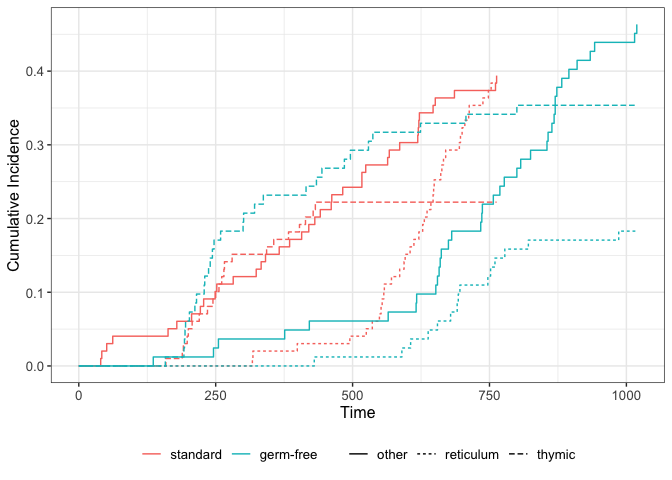

```r
ci_m <- cuminc(Surv(time, cause) ~ env, data = mice)
ggcuminc(ci_m, outcome = levels(mice$cause)[-1])
```

```r
(tests_m <- broom::glance(ci_m) |>
  pivot_longer(everything(), names_to = c(".value", "index"), names_sep = "_") |>
  select(-index))
```

```
#> # A tibble: 3 × 4
#>   outcome   statistic    df  p.value
#>   <chr>         <dbl> <dbl>    <dbl>
#> 1 thymic         2.90     1 0.0888
#> 2 reticulum     13.9      1 0.000194
#> 3 other          6.64     1 0.00997
```

```r
gray_other <- tests_m |> filter(outcome == "other") |> pull(p.value)
```

`glance()` extracts Gray’s test for each outcome. The reshaping puts each outcome and its p-value on one row.

- *Thymic lymphoma*: the germ-free curve is already higher during parts of early follow-up, and the gap is clearer later.
- *Reticulum cell sarcoma*: the germ-free incidence is lower through almost the whole follow-up.
- *Other causes*: the standard group has a higher cumulative incidence through most of the observed follow-up. The germ-free curve eventually exceeds the standard group’s terminal plateau. Collett’s Figure 12.3 extends both curves to the end of the study and shows the crossing.

Crossing cumulative incidence curves are incompatible with proportional subhazards. Question 13 examines that assumption for “other”.

3. With no censoring every mouse contributes an observed death, so the three cumulative incidences must sum to exactly 1 at the last observed time in each group. The estimated ultimate probability for each cause is the proportion of mice that died from that cause.

```r
(ult <- prop.table(table(mice$env, mice$cause), margin = 1))
```

```
#>
#>             censored thymic reticulum other
#>   standard      0.00   0.22      0.38  0.39
#>   germ-free     0.00   0.35      0.18  0.46
```

```r
followup <- summarise(mice, last = max(time), median = median(time), .by = env)
followup
```

```
#>         env last median
#> 1  standard  763    495
#> 2 germ-free 1019    655
```

```r
tidy(ci_m, times = followup$last) |>
  inner_join(followup, by = c("strata" = "env", "time" = "last")) |>
  summarise(total_cif = sum(estimate), .by = c(strata, time))
```

```
#> # A tibble: 2 × 3
#>   strata     time total_cif
#>   <fct>     <dbl>     <dbl>
#> 1 standard    763         1
#> 2 germ-free  1019         1
```

The last follow-up time in each group is the time of its last death. These times can differ because the groups have different observed survival times. The median survival times in the table compare the groups using more than their last observations.

## Solution 11

```r
mice_causes <- levels(mice$cause)[-1]
cs_mice <- map(setNames(mice_causes, mice_causes), \(x) {
  coxph(Surv(time, cause == x) ~ env, data = mice)
})
cs_mice |>
  modelsummary::modelsummary(
    exponentiate = TRUE,
    estimate = "{estimate} ({conf.low}, {conf.high})",
    statistic = "{p.value}",
    output = "markdown"
  )
```

|  | thymic | reticulum | other |
| --- | --- | --- | --- |
| envgerm-free | 1.359 (0.775, 2.383) | 0.131 (0.067, 0.258) | 0.308 (0.171, 0.552) |
|  | 0.284 | <0.001 | <0.001 |
| Num.Obs. | 181 | 181 | 181 |
| AIC | 497.1 | 385.6 | 589.9 |
| BIC | 500.3 | 388.8 | 593.1 |
| RMSE | 0.53 | 0.53 | 0.64 |

```r
fg_mice <- map(setNames(mice_causes, mice_causes), \(x) {
  crr(Surv(time, cause) ~ env, data = mice, failcode = x)
})
fg_mice |>
  modelsummary::modelsummary(
    exponentiate = TRUE,
    estimate = "{estimate} ({conf.low}, {conf.high})",
    statistic = "{p.value}",
    output = "markdown"
  )
```

|  | thymic | reticulum | other |
| --- | --- | --- | --- |
| envgerm-free | 1.681 (0.967, 2.921) | 0.393 (0.220, 0.703) | 1.005 (0.644, 1.568) |
|  | 0.066 | 0.002 | 0.980 |
| Num.Obs. | 181 | 181 | 181 |
| Log.Lik. | -255.607 | -261.847 | -381.203 |

The estimates and intervals are close to Tables 12.8 and 12.9. The p-values in the R tables are Wald p-values.

## Solution 12

1. The subhazard at time $t$ equals $h_j(t)S(t)/\{1-F_j(t)\}$. The two ratios can differ because the groups also differ in their overall survivor functions and in the fraction that has already died from a competing cause. Many standard-group mice die early from other causes. They leave the cause-specific risk set but remain in the subdistribution risk set. The two fits therefore use different risk sets over time. Moreover, the constant Fine and Gray ratio for reticulum cell sarcoma is only a summary because the comparison varies with time, as shown in Question 13.
2. The fitted constant subhazard ratio near 1 can hide differences over time. The cumulative incidence of death from other causes starts out lower in the germ-free group and ends at 46.3 %, compared with 39.4 % in the standard group. This can happen alongside a lower estimated cause-specific hazard: the cumulative incidence function depends on both $h_j(t)$ and the overall survivor function $S(t)$. A larger $S(t)$ means more mice remain at risk of dying from that cause later.
3. With complete follow-up until death, the estimated ultimate probabilities answer the question directly. The proportion dying from reticulum cell sarcoma was 38.4 % in the standard group and 18.3 % in the germ-free group. If a model is needed, a Fine and Gray model can be used to predict the cumulative incidence function for each group, allowing the subhazard ratio to vary with time as shown in Question 13.
4. No. Gray’s test compares the cumulative incidence functions over follow-up without assuming proportional subhazards. The Fine and Gray model in Question 11(b) summarises the comparison with a single constant ratio. That ratio can be close to 1 when the groups differ in opposite directions at different times. Question 13 checks this explanation.

## Solution 13

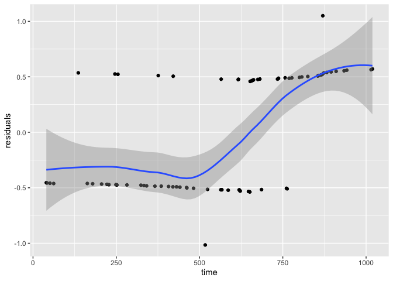

```r
q13a
```

With proportional subhazards, we expect the smooth to fluctuate around zero without a systematic trend. Here it is negative early and rises above zero later, suggesting a time-varying association. The plot uses unscaled Schoenfeld-type residuals against time in days. It is analogous to Collett’s diagnostic in Figure 12.4, which uses scaled residuals.

2. *Optional extension.*

```r
tibble(cause = mice_causes, p.value = q13b)
```

```
#> # A tibble: 3 × 2
#>   cause     p.value
#>   <chr>     <chr>
#> 1 thymic    0.161
#> 2 reticulum 0.0158
#> 3 other     5.3e-07
```

The p-values agree with the book. The interaction between the baseline environment and $\log(t)$ provides evidence against a constant subhazard ratio for reticulum cell sarcoma and other causes at the 5 % level. For thymic lymphoma, this test does not detect a departure.

The mice are uncensored, so the subdistribution risk sets use unit weights. In this case, the objective is the ordinary partial likelihood obtained by keeping competing-event subjects in the risk set through the last event of interest. That is why the likelihood ratio calculation applies here.

3. *Optional extension.*

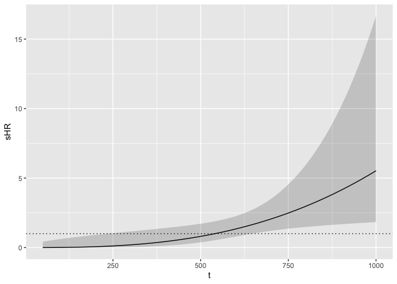

```r
q13c
```

On the plotted grid, the pointwise 95 % intervals lie entirely below 1 through day 235 and entirely above 1 from day 647. These intervals assess the subhazard ratio separately at each plotted time.

4. For deaths from other causes, the residual plot and likelihood ratio test give evidence against proportional subhazards. Report the time-dependent subhazard ratio with its pointwise intervals and show the cumulative incidence curves for the two groups. The germ-free group has a lower fitted subhazard early and a higher one late. For reticulum cell sarcoma the likelihood ratio test also gives evidence of non-proportionality. For thymic lymphoma it gives no clear evidence against a constant subhazard ratio.